# Modeling Physiological and Behavioral Predictors of Stress Using a Linear Mixed Model on Wearable Health Data

Using Synthetic Longitudinal Wearable Device Data

Author

Savannah Davis  
Bryce Mattos  
Jessica Jones  
Jordan Gainey  
(Advisor: Dr. Cohen)

Published

July 20, 2026

Slides: slides.html

## Introduction

Stress is a state where the emotional, psychological, or physiological systems of an individual experience a demand that exceeds their knowledge and ability to resolve. Whether perceived consciously or unconsciously, the body then responds by prompting organs and glands to produce hormones that will assist the individual in adapting to the situation. Normal physiological responses to acute stress are short-lived and allow the body to return to its natural state without any long-term consequences. However, chronic stress, which is the result of unresolved long-standing demands and challenges can result in physical complications and disease in the body (Can et al. 2022). In fact, the effects of chronic stress are so serious that research in Europe showed stress as the second most severe work-related health issue (Can et al. 2022). Insights on stress can of course be self-reported by individuals, however, more efficient and accurate means of tracking stress can be accomplished via wearable devices such as Fitbit and Garmin.

Wearable devices can collect a wide range of data such as: heart rate, heart rate variability (HRV), sleep quality, physical activity, and movement patterns (Namvari et al. 2022; Wang et al. 2024). Out of those variables, researchers select the physiological ones that are directly influenced by the autonomic nervous system (ANS), mainly because stress is fundamentally an ANS response. The ANS regulates involuntary bodily functions and also consists of the sympathetic (SNS) and parasympathetic nervous systems (PNS) which maintain homeostasis within the body (Chalmers et al. 2022). During periods of stress, the SNS activates which results in elevated heart rates and changes in HRV, which makes those important variables to include in stress prediction research. Additionally, sleep, physical activity, circadian rhythms, and environmental conditions also contribute to stress and researchers often incorporate them when developing stress prediction models (Wang et al. 2024; Kraaij et al. 2020).

While physiological variables such as heart rate and HRV provide valuable information about how the body responds to stress, researchers have found that behavioral and lifestyle factors also contribute to stress levels. Sleep duration, sleep quality, sleep efficiency, screen time, caffeine consumption, alcohol use, and mindfulness practices all have been shown to affect overall well-being (Vidal Bustamante et al. 2024; Booth et al. 2022). Out of those listed factors, sleep has been identified as one of the strongest predictors of perceived stress, as disruptions influence an individual’s ability to adapt to daily demands (Bloomfield 2024). So, to increase the accuracy of stress prediction, researchers have concluded that combining physiological signals with lifestyle factors improves the ability to predict individuals experiencing higher levels of stress (Sano et al. 2018). More recent work has also shown that wearable devices can successfully identify periods of stress in real-world environments, further demonstrating their potential for continuous stress monitoring (Neigel et al. 2024).

Based on previous research, both physiological and behavioral measures appear to contribute to stress. Publicly available wearable datasets, such as WESAD, have also contributed to the development and evaluation of stress detection models using wearable data by providing benchmark data for physiological stress research (Schmidt et al. 2018). Building on this body of research, this study examines these relationships using a synthetic longitudinal wearable dataset consisting of 300 participants observed over a six-month period, resulting in more than 55,000 observations. The dataset includes physiological and behavioral measures such as heart rate variability (HRV), sleep duration, sleep efficiency, caffeine consumption, alcohol use, screen time, mindfulness, and physical activity, along with daily stress scores.

The purpose of this study is to identify physiological and behavioral predictors of stress using longitudinal wearable health data and evaluate the ability of a linear mixed model (LMM) to predict stress scores over time. Because the dataset contains repeated measurements from the same participants, a linear mixed model was selected to account for the correlation among observations collected from the same individual. Linear mixed models are well suited for longitudinal data because they account for repeated observations while capturing both population-level trends and variation between individuals (Silveira et al. 2023; Harrison et al. 2018).

## Methods

#### Linear Mixed Model Overview

An LMM is commonly used when the outcome variable is continuous and the data contain grouped, clustered, longitudinal, or repeated measurements (Detry and Ma 2016; Harrison et al. 2018; Murphy et al. 2022). Unlike a standard linear regression, an LMM can account for situations where multiple observations come from the same subject or group. In this project, each participant contributes daily wearable measurements over a six-month period. A standard linear regression assumes that observations are independent, so that assumption is violated for this dataset. A linear mixed model accounts for the repeated observations within each participant while still estimating the overall relationship between the predictor variables and stress score.

A linear mixed model extends standard linear regression by including both fixed effects and random effects. Fixed effects estimate the average relationship between the predictor variables and the outcome across all participants. Random effects account for differences between participants by allowing each one to have their own baseline value. Together, these two components make the model well suited for repeated-measures data where observations are nested within individuals (Harrison et al. 2018).

#### General Model Form

The general form of a linear mixed model can be written as:

$${y} = {X}{\beta} + {Z}{u} + {\varepsilon}$$
In this equation, ${X}{\beta}$ represents the fixed-effect portion of the model, or the average relationship between the predictor variables and the outcome. The term ${Z}{u}$ represents the random-effect portion of the model, which accounts for differences between users. The residual error term, ${\varepsilon}$, represents the variation that is not explained by either the fixed or random effects.

#### Repeated-Measures Structure

For repeated-measures data, the model can also be written at the observation level as:

$$y_{ij}
=
\beta_0
+
\beta_1X_{1ij}
+
\beta_2X_{2ij}
+
\cdots
+
\beta_pX_{pij}
+
b_{0i}
+
\varepsilon_{ij}$$
where:

- $y_{ij}$ = observed stress score for participant $i$ on day $j$
- $\beta_0$ = fixed intercept
- $\beta_k$ = fixed-effect coefficient for predictor $k$
- $X_{kij}$ = observed value of predictor $k$ for participant $i$ on day $j$
- $b_{0i}$ = participant-specific random intercept
- $\varepsilon_{ij}$ = residual error

#### Project Model

The model used in this project can be represented generally as:

stress_score ~ daily predictors + (1 | user_id)

The term (1 | user_id) specifies a random intercept for each participant. This allows the model to account for repeated observations from the same participant instead of treating every row as completely independent. The daily predictor variables are treated as fixed effects because the goal is to estimate their average relationship with stress score across the full dataset.

This model fits the project because the dataset contains daily wearable measurements from 300 simulated participants over approximately six months. Since each participant contributes multiple observations, the data have a repeated-measures structure with observations nested within participants. A linear mixed model accounts for this structure while estimating the relationship between the daily predictor variables and stress score.

#### Parameter Estimation

The linear mixed model was estimated using restricted maximum likelihood (REML), which is the default estimation method used by the lmer() function in R. REML is commonly used because it generally provides less biased estimates of the random-effect variance than ordinary maximum likelihood estimation. Since this project focused on fitting a final model rather than comparing multiple competing models, REML was appropriate for the analysis.

#### Model Assumptions

The main assumptions of a linear mixed model are:

- The relationship between the predictor variables and the outcome is approximately linear.
- The residual errors are approximately normally distributed.
- The residual variance is reasonably consistent across fitted values.
- The random effects are approximately normally distributed with a mean of zero.
- The random effects and residual errors are independent of one another.

Violations of these assumptions can affect model performance and the validity of statistical conclusions, making it important to evaluate diagnostic plots before interpreting the results (Yang 2014).

#### Interpretation

The fixed effects describe the average relationship between the wearable, physiological, sleep, and behavioral predictors and stress score across all participants. The random intercept accounts for differences in baseline stress between participants while recognizing that repeated observations from the same participant are related. By accounting for this repeated-measures structure, the model provides a more appropriate analysis than a standard linear regression for this type of data.

Because the dataset is synthetic, the results should be interpreted as a demonstration of the modeling approach rather than clinical evidence. The purpose of this analysis is to demonstrate how a linear mixed model can be used to analyze repeated wearable measurements while accounting for the correlation between observations from the same participant.

## Analysis and Results

### Data Exploration and Visualization

This report utilizes the *Health + Wellness + Stress/Sleep Tracking (Synthetic)* dataset obtained from Kaggle (Akarsu 2025). The dataset contains wearable health and behavioral measurements for 300 simulated participants over a 6-month period. The dataset contains demographic, physiological, behavioral, and sleep-related variables collected daily from wearable devices. A linear mixed model is appropriate for this dataset because observations from the same participant are not independent, violating a key assumption of ordinary linear regression.

```r
library(tidyverse)
library(knitr)
library(kableExtra)
library(corrplot)
library(lme4)
library(lmerTest)
library(performance)
library(broom.mixed)
library(car)
```

```r
# Load Data

df = read_csv("wearables_health_6mo_daily.csv")

# Rename variables to readable labels
variable_labels <- c(
  age = "Age",
  height_cm = "Height (cm)",
  weight_kg = "Weight (kg)",
  gender = "Gender",
  bmi = "BMI",
  resting_hr_bpm = "Resting Heart Rate",
  avg_hr_day_bpm = "Avg Heart Rate",
  hrv_rmssd_ms = "HRV (RMSSD)",
  spo2_avg_pct = "Average SpO₂ (%)",
  sbp_mmHg = "Systolic Blood Pressure",
  dbp_mmHg = "Diastolic Blood Pressure",
  steps = "Steps",
  distance_km = "Distance (km)",
  calories_kcal = "Calories",
  workout_minutes = "Workout Duration (min)",
  caffeine_mg = "Caffeine Intake (mg)",
  alcohol_units = "Alcohol Units",
  screen_time_min = "Screen Time (min)",
  mindfulness_minutes = "Mindfulness (min)",
  sleep_duration_hours = "Sleep Duration (hours)",
  sleep_efficiency = "Sleep Efficiency",
  sleep_latency_min = "Sleep Latency (min)",
  wake_after_sleep_onset_min = "Wake After Sleep Onset (min)",
  sleep_stage_rem_pct = "REM Sleep (%)",
  sleep_stage_deep_pct = "Deep Sleep (%)",
  sleep_stage_light_pct = "Light Sleep (%)",
  stress_score = "Stress Score"
)
```

```r
# Quick overview of dataset

dataset_overview <- tibble(
  Metric = c("Total Observations", "Total Variables", "Unique Participants"),
  Value = c(
    scales::comma(nrow(df)),
    scales::comma(ncol(df)),
    scales::comma(n_distinct(df$user_id))
  )
)

dataset_overview %>%
  kable(caption = "Table 1. Dataset Overview") %>%
  kable_styling(
    bootstrap_options = c("striped", "hover", "condensed"),
    full_width = FALSE
  )
```

Table 1. Dataset Overview

| Metric | Value |
| --- | --- |
| Total Observations | 55,200 |
| Total Variables | 33 |
| Unique Participants | 300 |

The raw dataset contains over 55,000 records for 300 distinct participants, with over 30 variables available for model development.

#### Missing Values

The dataset is investigated for missing values to assess next steps for preprocessing.

```r
# Investigating missing values

missing_values <- df %>%
  summarise(across(everything(), ~sum(is.na(.)))) %>%
  pivot_longer(
    cols = everything(),
    names_to = "Variable",
    values_to = "Missing_Values"
  ) %>%
  mutate(
    Percent_Missing = round(100 * Missing_Values / nrow(df), 2)
  ) %>%
  filter(
    Percent_Missing > 0
  ) %>%
  arrange(desc(Missing_Values)) %>%
  mutate(
    Variable = ifelse(
      Variable %in% names(variable_labels),
      variable_labels[Variable],
      Variable
    ),
    Missing_Values = scales::comma(Missing_Values)
  )

missing_values %>%
  rename(
    `Missing Values` = Missing_Values,
    `Percent Missing` = Percent_Missing
  ) %>%
  kable(
    caption = "Table 2. Missing Values by Variable"
  ) %>%
  kable_styling(
    bootstrap_options = c(
      "striped",
      "hover",
      "condensed"
    ),
    full_width = FALSE
  )
```

Table 2. Missing Values by Variable

| Variable | Missing Values | Percent Missing |
| --- | --- | --- |
| Avg Heart Rate | 1,057 | 1.91 |
| HRV (RMSSD) | 1,057 | 1.91 |
| Steps | 1,057 | 1.91 |
| Distance (km) | 1,057 | 1.91 |
| Calories | 1,057 | 1.91 |
| Sleep Duration (hours) | 1,057 | 1.91 |
| Sleep Efficiency | 1,057 | 1.91 |
| Sleep Latency (min) | 1,057 | 1.91 |
| Wake After Sleep Onset (min) | 1,057 | 1.91 |
| REM Sleep (%) | 1,057 | 1.91 |
| Deep Sleep (%) | 1,057 | 1.91 |
| Light Sleep (%) | 1,057 | 1.91 |

```r
# Count rows containing at least one missing value

rows_with_missing <- sum(!complete.cases(df))

# Calculate percentage of dataset removed

pct_rows_removed <- round(
  100 * rows_with_missing / nrow(df),
  2
)

missing_summary <- tibble(
  "Total Observations" = scales::comma(nrow(df)),
  "Rows With Missing" = scales::comma(rows_with_missing),
  "Percent Removed" = paste0(pct_rows_removed, "%")
)

missing_summary %>%
  kable(
    caption = "Table 3. Impact of Missing Data Removal"
  ) %>%
  kable_styling(
    bootstrap_options = c("striped", "hover", "condensed"),
    full_width = FALSE
  )
```

Table 3. Impact of Missing Data Removal

| Total Observations | Rows With Missing | Percent Removed |
| --- | --- | --- |
| 55,200 | 1,057 | 1.91% |

Table 3 reveals that less than 2% of the observations contained at least one missing value, with missing values occurring across several physiological, behavioral, and sleep-related variables. Because only 1.9% of the observations contained missing data, a complete-case analysis was performed by removing incomplete observations prior to model fitting. This resulted in a relatively small loss of data while simplifying the subsequent analyses.

```r
# Remove null values since there aren't many
df_clean <- na.omit(df)

# Convert categorical data to factor
df_clean <- df_clean %>%
  mutate(
    user_id = as.factor(user_id),
    gender = as.factor(gender),
    region = as.factor(region),
    device_model = as.factor(device_model),
    workout_type = as.factor(workout_type),
    mood = as.factor(mood)
  )

# Select all categorical variables
categorical_vars <- df_clean %>%
  select(
    user_id,
    gender,
    region,
    device_model,
    workout_type,
    mood
  )

# Select all continuous variables
continuous_vars <- df_clean %>%
  select(
    age, height_cm, weight_kg, bmi, resting_hr_bpm,
    avg_hr_day_bpm, hrv_rmssd_ms, spo2_avg_pct, sbp_mmHg,
    dbp_mmHg, steps, distance_km, calories_kcal,
    workout_minutes, caffeine_mg, alcohol_units, screen_time_min,
    sleep_duration_hours, sleep_efficiency, sleep_latency_min,
    wake_after_sleep_onset_min, sleep_stage_rem_pct, sleep_stage_deep_pct,
    sleep_stage_light_pct, mindfulness_minutes
  )
```

#### Descriptive Statistics

```r
# Function to create descriptive statistics tables

create_descriptive_table <- function(data, variables, caption) {

  data %>%
    select(all_of(variables)) %>%
    pivot_longer(
      cols = everything(),
      names_to = "Variable",
      values_to = "Value"
    ) %>%
    group_by(Variable) %>%
    summarise(
      Mean = round(mean(Value, na.rm = TRUE), 2),
      SD = round(sd(Value, na.rm = TRUE), 2),
      Min = round(min(Value, na.rm = TRUE), 2),
      Median = round(median(Value, na.rm = TRUE), 2),
      Max = round(max(Value, na.rm = TRUE), 2),
      .groups = "drop"
    ) %>%
        mutate(
      Variable = ifelse(
        Variable %in% names(variable_labels),
        variable_labels[Variable],
        Variable
      )
    ) %>%
    kable(caption = caption) %>%
    kable_styling(
      bootstrap_options = c(
        "striped",
        "hover",
        "condensed"
      ),
      full_width = FALSE
    )
}
```

The variables in the dataset are split into several different categories to assist in choosing variables of interest. Descriptive statistics tables will be created for each category including the mean, standard deviation, minimum, median, and maximum values.

```r
# Demographic fields

create_descriptive_table(
  df_clean,
  c(
    "age",
    "height_cm",
    "weight_kg",
    "bmi"
  ),
  "Table 4. Demographic Characteristics"
)
```

Table 4. Demographic Characteristics

| Variable | Mean | SD | Min | Median | Max |
| --- | --- | --- | --- | --- | --- |
| Age | 31.52 | 7.60 | 18.0 | 31.0 | 57.0 |
| BMI | 24.52 | 4.62 | 14.1 | 24.4 | 37.9 |
| Height (cm) | 172.30 | 9.47 | 150.0 | 172.0 | 200.0 |
| Weight (kg) | 72.29 | 11.76 | 45.0 | 72.6 | 100.8 |

```r
# Physiological fields

create_descriptive_table(
  df_clean,
  c(
    "resting_hr_bpm",
    "avg_hr_day_bpm",
    "hrv_rmssd_ms",
    "spo2_avg_pct",
    "sbp_mmHg",
    "dbp_mmHg"
  ),
  "Table 5. Physiological Characteristics"
)
```

Table 5. Physiological Characteristics

| Variable | Mean | SD | Min | Median | Max |
| --- | --- | --- | --- | --- | --- |
| Avg Heart Rate | 87.10 | 10.35 | 55 | 86.98 | 127.27 |
| Diastolic Blood Pressure | 77.20 | 8.09 | 55 | 77.37 | 110.00 |
| HRV (RMSSD) | 42.49 | 15.26 | 10 | 42.41 | 112.11 |
| Resting Heart Rate | 64.52 | 8.18 | 42 | 64.29 | 94.12 |
| Systolic Blood Pressure | 120.62 | 11.56 | 95 | 120.28 | 164.88 |
| Average SpO₂ (%) | 97.34 | 0.96 | 89 | 97.37 | 100.00 |

```r
# Behavioral fields

create_descriptive_table(
  df_clean,
  c(
    "steps",
    "distance_km",
    "calories_kcal",
    "workout_minutes",
    "caffeine_mg",
    "alcohol_units",
    "screen_time_min",
    "mindfulness_minutes"
  ),
  "Table 6. Behavioral Characteristics"
)
```

Table 6. Behavioral Characteristics

| Variable | Mean | SD | Min | Median | Max |
| --- | --- | --- | --- | --- | --- |
| Alcohol Units | 0.39 | 0.41 | 0.00 | 0.30 | 3.57 |
| Caffeine Intake (mg) | 149.04 | 93.57 | 0.00 | 144.25 | 474.81 |
| Calories | 2074.01 | 259.00 | 1200.00 | 2070.00 | 3188.00 |
| Distance (km) | 7.43 | 3.26 | 0.15 | 7.10 | 24.46 |
| Mindfulness (min) | 9.00 | 5.67 | 0.00 | 9.00 | 33.00 |
| Screen Time (min) | 243.24 | 95.49 | 30.00 | 241.94 | 752.02 |
| Steps | 9278.28 | 4012.85 | 200.00 | 8925.00 | 29651.00 |
| Workout Duration (min) | 26.12 | 20.22 | 0.00 | 28.00 | 110.00 |

```r
# Sleep fields

create_descriptive_table(
  df_clean,
  c(
    "sleep_duration_hours",
    "sleep_efficiency",
    "sleep_latency_min",
    "wake_after_sleep_onset_min",
    "sleep_stage_rem_pct",
    "sleep_stage_deep_pct",
    "sleep_stage_light_pct"
  ),
  "Table 7. Sleep Characteristics"
)
```

Table 7. Sleep Characteristics

| Variable | Mean | SD | Min | Median | Max |
| --- | --- | --- | --- | --- | --- |
| Sleep Duration (hours) | 6.99 | 0.84 | 3.50 | 6.99 | 10.50 |
| Sleep Efficiency | 0.88 | 0.09 | 0.60 | 0.89 | 0.99 |
| Sleep Latency (min) | 19.49 | 8.30 | 2.00 | 19.00 | 55.00 |
| Deep Sleep (%) | 0.20 | 0.07 | 0.05 | 0.20 | 0.41 |
| Light Sleep (%) | 0.56 | 0.08 | 0.30 | 0.56 | 0.87 |
| REM Sleep (%) | 0.23 | 0.05 | 0.06 | 0.23 | 0.41 |
| Wake After Sleep Onset (min) | 36.93 | 10.66 | 0.00 | 37.00 | 81.00 |

```r
# Outcome variable

create_descriptive_table(
  df_clean,
  c(
    "stress_score"
  ),
  "Table 8. Stress Score Summary"
)
```

Table 8. Stress Score Summary

| Variable | Mean | SD | Min | Median | Max |
| --- | --- | --- | --- | --- | --- |
| Stress Score | 67.05 | 11.75 | 19 | 67 | 100 |

#### Stress Distribution

Before fitting the linear mixed model, the distribution of the outcome variable is examined. Looking at the distribution of stress scores provides a better understanding of the data and helps identify any obvious issues such as extreme skewness or outliers.

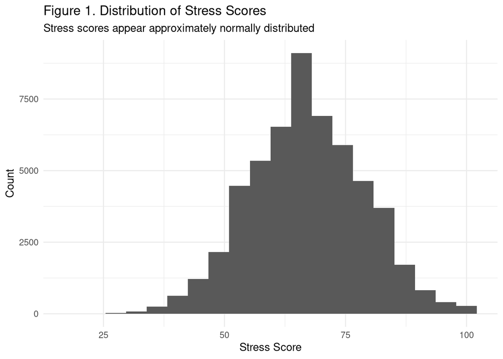

```r
# Investigating distribution of stress score within the dataset

ggplot(df_clean, aes(x = stress_score)) +
  geom_histogram(bins = 20) +
  labs(
    title = "Figure 1. Distribution of Stress Scores",
    subtitle = "Stress scores appear approximately normally distributed",
    x = "Stress Score",
    y = "Count"
  ) +
  theme_minimal()
```

Figure 1 shows that the distribution appears to be approximately normal with no extreme outliers.

### Modeling and Results

#### Variable Selection

Before fitting the model, the continuous variables were checked for correlation. Highly correlated predictors can provide overlapping information, making it difficult to determine the individual effect of each variable. The correlation heatmap was used to identify highly correlated predictor variables prior to model fitting.

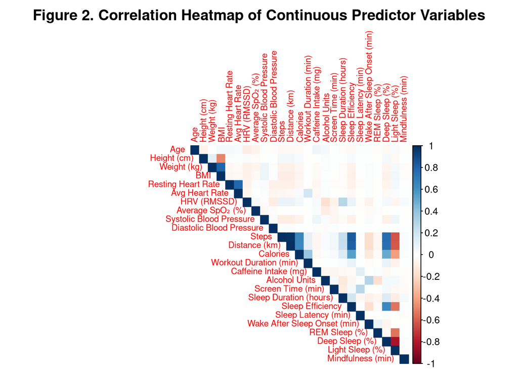

```r
# Calculate correlation matrix for continuous variables
# Helps identify correlated variables before building model
continuous_vars_plot <- continuous_vars

colnames(continuous_vars_plot) <- ifelse(
  colnames(continuous_vars_plot) %in% names(variable_labels),
  variable_labels[colnames(continuous_vars_plot)],
  colnames(continuous_vars_plot)
)

# Correlation matrix
corr_matrix <- cor(
  continuous_vars_plot,
  use = "complete.obs"
)

# Correlation heatmap
corrplot(
  corr_matrix,
  method = "color",
  type = "upper",
  tl.cex = 0.7,
  title = "Figure 2. Correlation Heatmap of Continuous Predictor Variables",
  mar = c(0, 0, 2, 0)
)
```

```r
# Create table from the corr matrix
corr_table <- as.data.frame(as.table(corr_matrix)) %>%
  rename(
    Variable1 = Var1,
    Variable2 = Var2,
    Correlation = Freq
  ) %>%
  filter(
    as.character(Variable1) < as.character(Variable2)
  ) %>%
  mutate(
    abs_corr = abs(Correlation)
  ) %>%
  arrange(desc(abs_corr))

# Filter to only the highly correlated pairs and remove duplicate pairs
corr_table %>%
  filter(abs_corr >= 0.70) %>%
  mutate(
    Correlation = round(Correlation, 2)
  ) %>%
  select(
    Variable1,
    Variable2,
    Correlation
  ) %>%
  kable(
    caption = "Table 9. Strong correlations among predictor variables"
  ) %>%
  kable_styling(full_width = FALSE)
```

Table 9. Strong correlations among predictor variables

| Variable1 | Variable2 | Correlation |
| --- | --- | --- |
| Distance (km) | Steps | 0.98 |
| Sleep Efficiency | Steps | 0.83 |
| Deep Sleep (%) | Light Sleep (%) | -0.83 |
| Distance (km) | Sleep Efficiency | 0.82 |
| BMI | Weight (kg) | 0.81 |
| Avg Heart Rate | Resting Heart Rate | 0.79 |
| Deep Sleep (%) | Steps | 0.77 |
| Deep Sleep (%) | Distance (km) | 0.75 |

```r
# Build initial model with all variables (except ones with strong correlations)
# Put user_id as the random effect

lmm_full <- lmer(
  stress_score ~
    age +
    gender +
    region +
    device_model +
    workout_type +
    bmi +
    resting_hr_bpm +
    hrv_rmssd_ms +
    spo2_avg_pct +
    sbp_mmHg +
    dbp_mmHg +
    distance_km +
    workout_minutes +
    caffeine_mg +
    alcohol_units +
    screen_time_min +
    mindfulness_minutes +
    sleep_duration_hours +
    sleep_efficiency +
    sleep_latency_min +
    wake_after_sleep_onset_min +
    (1 | user_id),
  data = df_clean
)

#summary(lmm_full)
```

```r
# Reduced model after getting rid of irrelevant variables
# Variables with weak effects and little explanatory value were removed

lmm_final <- lmer(
  stress_score ~
    workout_type +
    hrv_rmssd_ms +
    distance_km +
    caffeine_mg +
    alcohol_units +
    screen_time_min +
    mindfulness_minutes +
    sleep_duration_hours +
    sleep_efficiency +
    wake_after_sleep_onset_min +
    (1 | user_id),
  data = df_clean
)

#summary(lmm_final)
```

Variables that demonstrated limited contribution to the interpretation of the initial model were removed to simplify the model while retaining the primary wearable health measures of interest. The final model included workout type, HRV, distance traveled, caffeine intake, alcohol consumption, screen time, mindfulness minutes, sleep duration, sleep efficiency, and wake after sleep onset.

Overall, the reduced model was easier to interpret while maintaining the primary relationships between the wearable health variables and stress score.

#### Model Results

```r
# This table summarizes the fixed effects retained in the final model

coef_table <- broom.mixed::tidy(
  lmm_final,
  conf.int = TRUE,
  conf.level = 0.95
)

coef_table %>%
  filter(effect == "fixed") %>%
  select(
    term,
    estimate,
    conf.low,
    conf.high,
    p.value
  ) %>%
  mutate(
    term = case_when(
      term == "(Intercept)" ~ "Intercept",
      grepl("^workout_type", term) ~
        paste0("Workout Type: ", sub("^workout_type", "", term)),
      TRUE ~ ifelse(
        term %in% names(variable_labels),
        variable_labels[term],
        term
      )
    ),
    estimate = round(estimate, 3),
    `95% CI` = paste0(
      "(",
      round(conf.low, 4),
      ", ",
      round(conf.high, 4),
      ")"
    ),
    p.value = ifelse(
      p.value < .001,
      "<0.001",
      round(p.value, 4)
    )
  ) %>%
  select(
    term,
    estimate,
    `95% CI`,
    p.value
  ) %>%
  kable(
    col.names = c(
      "Variable",
      "Coefficient",
      "95% Confidence Interval",
      "p-value"
    ),
    caption = "Table 10. Fixed Effects from Final Linear Mixed Model"
  ) %>%
  kable_styling(
    bootstrap_options = c(
      "striped",
      "hover",
      "condensed"
    ),
    full_width = FALSE
  )
```

Table 10. Fixed Effects from Final Linear Mixed Model

| Variable | Coefficient | 95% Confidence Interval | p-value |
| --- | --- | --- | --- |
| Intercept | 116.118 | (115.1634, 117.0725) | <0.001 |
| Workout Type: mixed | -0.135 | (-0.4284, 0.1593) | 0.3694 |
| Workout Type: none | 0.084 | (-0.0936, 0.2612) | 0.3544 |
| Workout Type: run | -0.195 | (-0.39, 3e-04) | 0.0503 |
| Workout Type: strength | 0.093 | (-0.1159, 0.3029) | 0.3816 |
| Workout Type: walk | -0.169 | (-0.3597, 0.0219) | 0.0827 |
| Workout Type: yoga | 0.153 | (-0.0815, 0.388) | 0.2008 |
| HRV (RMSSD) | -0.258 | (-0.2628, -0.2528) | <0.001 |
| Distance (km) | -0.442 | (-0.4728, -0.4113) | <0.001 |
| Caffeine Intake (mg) | 0.040 | (0.0387, 0.0404) | <0.001 |
| Alcohol Units | 4.577 | (4.407, 4.7472) | <0.001 |
| Screen Time (min) | 0.032 | (0.0317, 0.0331) | <0.001 |
| Mindfulness (min) | -0.042 | (-0.0508, -0.0326) | <0.001 |
| Sleep Duration (hours) | -5.974 | (-6.042, -5.9057) | <0.001 |
| Sleep Efficiency | -9.564 | (-10.5974, -8.5301) | <0.001 |
| Wake After Sleep Onset (min) | 0.005 | (1e-04, 0.0103) | 0.0473 |

Table 10 presents the estimated fixed-effect coefficients, 95% confidence intervals, and p-values for the final linear mixed model. The coefficients represent the estimated association between each predictor and stress score while accounting for the repeated measurements collected from each participant.

Several physiological and behavioral variables were significantly associated with stress score. Higher heart rate variability (HRV), greater distance traveled, more mindfulness minutes, longer sleep duration, and higher sleep efficiency were associated with lower stress scores. In contrast, greater caffeine intake, alcohol consumption, screen time, and waking after sleep onset were associated with higher stress scores. For each of these predictors, the 95% confidence interval did not include zero, providing evidence of a statistically significant association with stress score.

None of the workout type indicator variables were statistically significant after accounting for the remaining predictors. Although participants who reported running tended to have slightly lower stress scores than the reference group, the estimated effect was small and the 95% confidence interval included zero. Although workout type was not statistically significant, it was retained because physical activity is an important behavioral variable in wearable health research and was included to evaluate whether different forms of exercise were associated with stress after accounting for other physiological and behavioral measures.

#### Final Fitted Model

The final fitted model can be written as:

$$\begin{aligned}
\widehat{\text{Stress Score}}_{ij}
&= 116.118
-0.135(\text{Workout}_{\text{Mixed}})
+0.084(\text{Workout}_{\text{None}})
-0.195(\text{Workout}_{\text{Run}})\\
&\quad
+0.093(\text{Workout}_{\text{Strength}})
-0.169(\text{Workout}_{\text{Walk}})
+0.153(\text{Workout}_{\text{Yoga}})\\
&\quad
-0.258(\text{HRV})
-0.442(\text{Distance})
+0.040(\text{Caffeine})
+4.577(\text{Alcohol})\\
&\quad
+0.032(\text{Screen Time})
-0.042(\text{Mindfulness})
-5.974(\text{Sleep Duration})\\
&\quad
-9.564(\text{Sleep Efficiency})
+0.005(\text{Wake After Sleep Onset})
+b_{0i}.
\end{aligned}$$
where $i$ indexes participants, $j$ indexes daily observations, and $b_{0i}$ represents the participant-specific random intercept.

#### Model Assumptions Check

###### Figure 3. Normality of Residuals

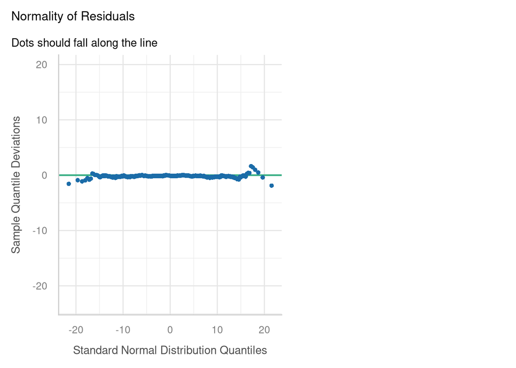

```r
# Check model diagnostics
check_model(lmm_final, check = "qq")
```

###### Figure 4. Homogeneity of Variance

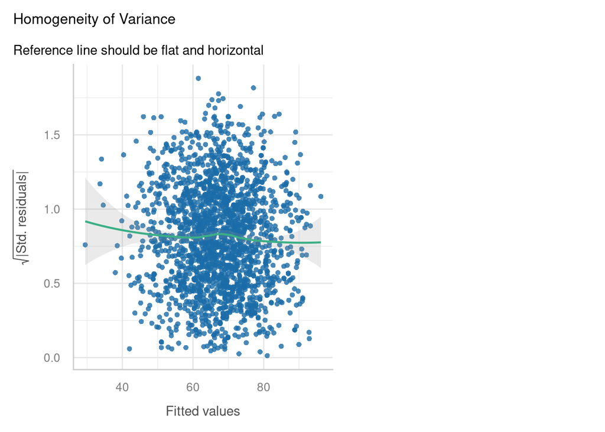

```r
# Check model diagnostics
check_model(lmm_final, check = "homogeneity")
```

###### Figure 5. Linearity

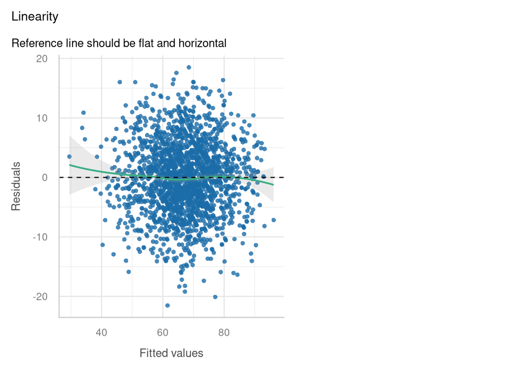

```r
# Check model diagnostics
check_model(lmm_final, check = "linearity")
```

###### Figure 6. Normality of Random Effects

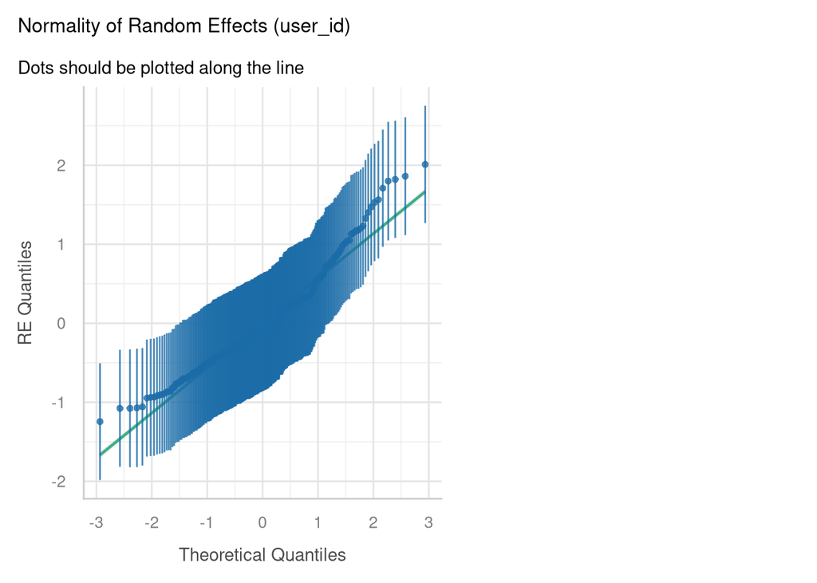

```r
check_model(lmm_final, check = "reqq")
```

The assumptions of the final linear mixed model were checked. Figure 3 shows that the residuals are approximately normally distributed, with only small departures from normality at the extreme ends of the distribution. Figure 4 shows a fairly consistent spread of the residuals across the fitted values, with no strong evidence of increasing or decreasing variance, suggesting that the assumption of homogeneity of variance was reasonably satisfied. Figure 5 shows no obvious patterns in the residuals versus the fitted values, indicating that the relationship between the predictors and stress score is approximately linear. Finally, Figure 6 shows that the participant-specific random effects are approximately normally distributed, with only minor deviations from the reference line in the tails. Overall, these diagnostic plots suggest that the assumptions of the linear mixed model were reasonably satisfied.

#### Model Performance

```r
# Calculate model performance metrics

r2_vals <- performance::r2(lmm_final)

icc_val <- performance::icc(lmm_final)

# Residuals from final model
model_residuals <- resid(lmm_final)

# Error metrics
rmse <- sqrt(mean(model_residuals^2))

mae <- mean(abs(model_residuals))

performance_table <- tibble(
  Metric = c(
    "Marginal R²",
    "Conditional R²",
    "ICC",
    "RMSE",
    "MAE",
    "Participants",
    "Observations"
  ),
  Value = c(
    round(r2_vals$R2_marginal, 3),
    round(r2_vals$R2_conditional, 3),
    round(icc_val$ICC_adjusted, 3),
    round(rmse, 3),
    round(mae, 3),
    scales::comma(n_distinct(df_clean$user_id)),
    scales::comma(nrow(df_clean))
  )
)

performance_table %>%
  kable(
    caption = "Table 11. Final Model Performance Metrics"
  ) %>%
  kable_styling(
    bootstrap_options = c(
      "striped",
      "hover",
      "condensed"
    ),
    full_width = FALSE
  )
```

Table 11. Final Model Performance Metrics

| Metric | Value |
| --- | --- |
| Marginal R² | 0.726 |
| Conditional R² | 0.729 |
| ICC | 0.013 |
| RMSE | 6.072 |
| MAE | 4.844 |
| Participants | 300 |
| Observations | 54,143 |

Table 11 summarizes the overall performance of the final linear mixed model. The marginal $R^2$ of 0.726 indicates that the fixed effects explained approximately 72.6% of the variation in stress scores. The conditional $R^2$ was slightly higher (0.729), indicating that the participant-specific random intercept provided a modest additional contribution beyond the fixed effects. Likewise, the ICC of 0.013 suggests that relatively little of the remaining variation in stress scores was attributable to stable differences between participants.

Although the between-participant variability was relatively small, the linear mixed model remained appropriate because the dataset contained repeated daily observations from the same individuals. Including a participant-specific random intercept accounted for the correlation among observations collected from the same participant while allowing the fixed effects to estimate the relationships between the wearable health measures and stress.

The RMSE of 6.072 indicates a typical residual error of approximately six stress-score points, with larger prediction errors receiving greater weight. The MAE of 4.844 indicates that the fitted stress scores differed from the observed values by an average of approximately five points.

Collectively, these performance metrics indicate that the final model explained a substantial proportion of the variation in stress scores while maintaining relatively small residual errors across the observed data.

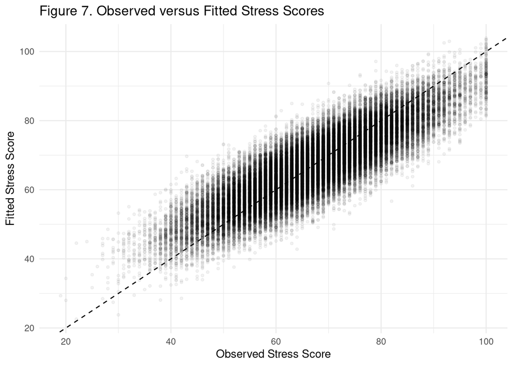

```r
# Observed versus fitted values

ggplot(
  data.frame(
    Observed = df_clean$stress_score,
    Fitted = fitted(lmm_final)
  ),
  aes(
    x = Observed,
    y = Fitted
  )
) +
  geom_point(
    alpha = 0.05,
    size = 1
  ) +
  geom_abline(
    slope = 1,
    intercept = 0,
    linetype = "dashed"
  ) +
  labs(
    title = "Figure 7. Observed versus Fitted Stress Scores",
    x = "Observed Stress Score",
    y = "Fitted Stress Score"
  ) +
  theme_minimal()
```

Figure 7 above compares the observed stress scores with the fitted values produced by the final linear mixed model. Most observations fall relatively close to the reference line, indicating that the fitted values generally correspond well with the observed stress scores. Although some variability remains, the overall pattern suggests that the model provides a good representation of the observed data.

## Conclusion

Overall, the final linear mixed model identified several physiological, behavioral, and sleep-related variables that were associated with stress within this synthetic wearable health dataset. In particular, measures related to heart rate variability, physical activity, sleep quality, mindfulness, caffeine intake, alcohol consumption, and screen time were significantly associated with stress after accounting for repeated measurements within participants. The final model satisfied the evaluated assumptions, explained a substantial proportion of the variation in stress scores, and provided a good overall fit to the observed data.

These findings demonstrate the value of linear mixed models for analyzing longitudinal wearable health data, where repeated observations from the same individuals violate the assumption of independent observations required by traditional linear regression. By incorporating participant-specific random effects, the model was able to account for within-participant correlation while estimating the relationships between wearable health measures and stress.

Because this study used a synthetic dataset, the findings should not be interpreted as evidence of real-world clinical relationships. However, the analysis illustrates how wearable health data and linear mixed modeling can be combined to investigate factors associated with stress and provides a framework that could be applied to real-world longitudinal health data in future research.

## References

Akarsu, Meftun. 2025. “Health + Wearables + Stress/Sleep Tracking (Synthetic).” Version 1. Kaggle. https://www.kaggle.com/datasets/mftnakrsu/health-wearables-stresssleep-tracking-syntc/data.

Bloomfield, Mikaela I. AND Kim, Laura S. P. AND Fudolig. 2024. “Predicting Stress in First-Year College Students Using Sleep Data from Wearable Devices.” *PLOS Digital Health* 3 (4): 1–16. https://doi.org/10.1371/journal.pdig.0000473.

Booth, B. M., H. Vrzakova, S. M. Mattingly, G. J. Martinez, L. Faust, and S. K. D’Mello. 2022. “Toward Robust Stress Prediction in the Age of Wearables: Modeling Perceived Stress in a Longitudinal Study with Information Workers.” *IEEE Transactions on Affective Computing* 13 (4): 2201–17. https://doi.org/10.1109/TAFFC.2022.3188006.

Can, Y. S., B. Arnrich, and C. Ersoy. 2022. “Stress Detection in Daily Life Scenarios Using Smart Phones and Wearable Sensors: A Survey.” *Journal of Biomedical Informatics* 134: 104205.

Chalmers, T., B. A. Hickey, P. Newton, et al. 2022. “Associations Between Sleep Quality and Heart Rate Variability: Implications for a Biological Model of Stress Detection Using Wearable Technology.” *International Journal of Environmental Research and Public Health* 19 (9): 5770. https://doi.org/10.3390/ijerph19095770.

Detry, Michelle A., and Yiqing Ma. 2016. “Analyzing Repeated Measurements Using Mixed Models.” *JAMA* 315 (4): 407–8. https://doi.org/10.1001/jama.2015.19394.

Harrison, Xavier A., Lynda Donaldson, Maria E. Correa-Cano, et al. 2018. “A Brief Introduction to Mixed Effects Modelling and Multi-Model Inference in Ecology.” *PeerJ* 6: e4794. https://doi.org/10.7717/peerj.4794.

Kraaij, A. van, G. Schiavone, E. Lutin, S. Claes, and C. Van Hoof. 2020. “Relationship Between Chronic Stress and Heart Rate over Time Modulated by Gender in a Cohort of Office Workers: Cross-Sectional Study Using Wearable Technologies.” *Journal of Medical Internet Research* 22 (9): e18253. https://doi.org/10.2196/18253.

Murphy, Jessica I., Nicholas E. Weaver, and Audrey E. Hendricks. 2022. “Accessible Analysis of Longitudinal Data with Linear Mixed Effects Models.” *Disease Models & Mechanisms* 15 (5): dmm048025. https://doi.org/10.1242/dmm.048025.

Namvari, M., J. Lipoth, S. Knight, et al. 2022. “Photoplethysmography Enabled Wearable Devices and Stress Detection: A Scoping Review.” *Journal of Personalized Medicine* 12 (11): 1792. https://doi.org/10.3390/jpm12111792.

Neigel, P., A. Vargo, B. Tag, and K. Kise. 2024. “Using Wearables to Unobtrusively Identify Periods of Stress in a Real University Environment.” *Proceedings of the 2024 ACM International Symposium on Wearable Computers*, 17–24. https://doi.org/10.1145/3675095.3676608.

Sano, A., S. Taylor, A. W. McHill, et al. 2018. “Identifying Objective Physiological Markers and Modifiable Behaviors for Self-Reported Stress and Mental Health Status Using Wearable Sensors and Mobile Phones: Observational Study.” *Journal of Medical Internet Research* 20 (6): e210. https://doi.org/10.2196/jmir.9410.

Schmidt, P., A. Reiss, R. Dürichen, C. Marberger, and K. Van Laerhoven. 2018. *Introducing WESAD, a Multimodal Dataset for Wearable Stress and Affect Detection*. 400–408. https://doi.org/10.1145/3242969.3242985.

Silveira, Luciana T. Y. D., Juliana C. Ferreira, and Carlos M. Patino. 2023. “Mixed-Effects Model: A Useful Statistical Tool for Longitudinal and Cluster Studies.” *Jornal Brasileiro de Pneumologia* 49 (2): e20230137. https://doi.org/10.36416/1806-3756/e20230137.

Vidal Bustamante, C. M., G. Coombs III, H. Rahimi-Eichi, et al. 2024. “Precision Assessment of Real-World Associations Between Stress and Sleep Duration Using Actigraphy Data Collected Continuously for an Academic Year: Individual-Level Modeling Study.” *JMIR Formative Research* 8: e53441. https://doi.org/10.2196/53441.

Wang, R., O. Rezaeian, O. Asan, L. Zhang, and T. Liao. 2024. “Relationship Between Heart Rate and Perceived Stress in Intensive Care Unit Residents: Exploratory Analysis Using Fitbit Data.” *JMIR Formative Research* 8: e60759. https://doi.org/10.2196/60759.

Yang, Zaitlen, J. 2014. “Advantages and Pitfalls in the Application of Mixed Model Association Methods.” *Nature Genetics* 46: 100–106. https://doi.org/10.1038/ng.2876.